# Protein Structural Comparisons

2025-12-04

# Introduction

Two key aspects of proteins determine their function: the amino acid/DNA sequence and structure. While protein/DNA sequencing methods have developed significantly in accuracy, efficiency, and cost in recent decades, this is not the case for protein structure. Until fairly recently (within the past few years), the only methods to nearly absolutely determine the structure of a protein were experimental, expensive and tedious, like x-ray diffraction. In x-ray diffraction, a protein is crystallized and beamed with x-rays, then the resulting diffraction patterns are used by a molecular visualization system to create an image of a cohesive structure.

With the rise of artificial intelligence, a new method has emerged, a system called AlphaFold. Now, anyone with the amino acid sequence of a protein can simply put it into AlphaFold and generate five predicted protein structures, ranked in order likelihood. However, the structures that this system generates do not always match the experimentally-determined structures. In drug-target research, using the wrong structure would be an enormous waste of time and money, since drugs are specifically designed to fit on/within the protein itself. Additionally, another version of AlphaFold was released earlier this year, but the previous version is still available. Therefore, the goal of my project was to compare/contrast 20 of the most studied human proteins through the following characteristics: protein classification, structure identification/prediction method (x-ray diffraction, AlphaFold 2, AlphaFold 3), number of amino acids in sequence, pTM, and RMSD.

## Key Terms

pTM: predicted template-modeling score; predicts the similarity between a protein model structure and the true protein structure; the score is a number between 0 and 1 with higher values indicating greater quality RMSD (in Å): root-mean square deviation (in angstroms); calculates the differences between predicted and observed values such as length in angstroms, and can be used to determine the similarity between two protein structures; the lower the number, the greater the similarity Resolution (in Å): measure of the smallest distance (in angstroms) between two objects that can be distinguished; the lower the number, the greater the detail; a distance of 1 angstrom means that individual atoms are distinguishable PyMOL: molecular visualization system that can convert raw x-ray diffraction data into a cohesive protein structure PDB: Protein Data Bank, a database for protein and DNA structural data; also refers to a file format in which structural data can be kept AlphaFold2 and 3: artificial intelligence program that can predict protein structures from amino acid sequences p-value: probability of obtaining the results through random chance and is used as a measure of data significance; the threshold/standard p-value to indicate extreme significance is <0.05

# Data Setup

To begin, I found a scientific paper that listed the most commonly studied proteins and set up a spreadsheet to record my findings. For the first 20 proteins I could find thorough PDB entries for, I took note of the name, PDB classification, PDB ID, and x-ray diffraction resolution. After downloading the PDB file for each protein, I then utilized the bio3d and tidyverse packages to 1) extract the amino acid sequences, and 2) convert them from a three-letter format to a one-letter format (which is what AlphaFold requires).

## Load Packages

```r
library(bio3d)
library(tidyverse)
```

## Amino Acid Sequence Extraction & 3-to-1 Conversion

```r
pdb_files <- list.files(path = "PDBs/", pattern = "\\.pdb$", full.names = TRUE)
all_sequences <- pdb_files %>%
  set_names(str_remove(basename(.), "\\.pdb$")) %>%
  map(~ read.pdb(.)$seqres %>%
        aa321() %>%
        paste(collapse = ""))
print(all_sequences)
```

[output not shown]

Once I copied each sequence to my spreadsheet, I ran the sequences through AlphaFold 2 and 3. (This was probably the most time-intensive portions of my project, with AlphaFold 2 taking at least an hour one the same sequences that would only take AlphaFold 3 ten minutes.) Both AlphaFold 2 and 3 give multiple protein structures and rank them from most-to-least likely as part of the output. Once I had all of the files, I organized the models with the highest ranking into their own folder and recorded the pTM values in my spreadsheet. I also utilized AlphaFold 3 to make note of the number of amino acids in each sequence. (Some of the PDB files were a little messy so any “character count” code I tried did not work well.)

Finally, it was time to align the structures using PyMOL. What is really neat about PyMOL is that is has a click-based interface and a command-line that runs Python, and I took the opportunity to use both. I used the command-line for uploading/naming each of the structures, as well as removing nucleic acid residues that sometimes came up in the x-ray diffraction files.

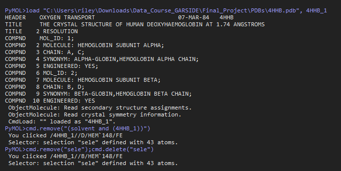

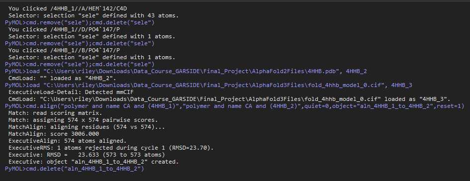

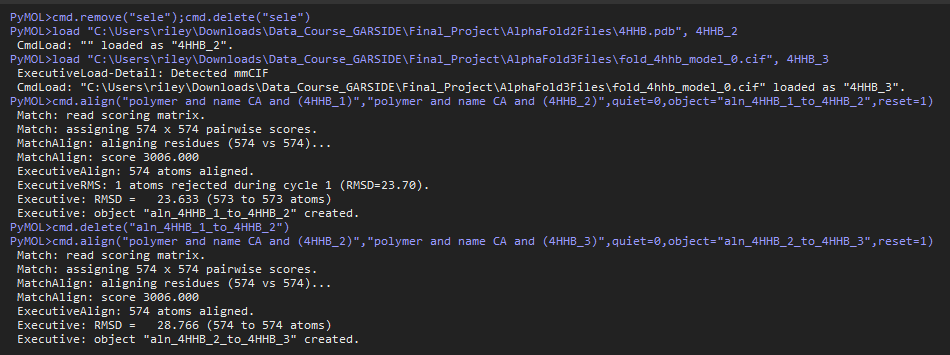

[figure not shown]

Example PyMOL commands and outputs (PDB 4HHB).

I used the click-based controls to remove water molecules, ligands and other atoms, then to perform the actual structural alignments using the “align to molecule” function. Interestingly enough, the command-line version of the alignment function would give out slightly different RMSD values than the click-based version. I was originally instructed by a professor who was familiar with PyMOL and protein structural alignments to use the “alignment to molecule” function, so that’s why I went that route. I recorded the RMSD values in my spreadsheet for the following comparisons:

X-Ray Diffraction to AlphaFold 2 X-Ray Diffraction to AlphaFold 3 AlphaFold 2 to AlphaFold 3

With the all of the alignments completed, I converted my spreadsheet to a .csv file and read my data into RStudio. For some reason, during the conversion my “Methods” column ended up with a lot of whitespace, which I used an additional line of code to get rid of.

```r
protein_df <- read.csv('Protein_Structures_Comparison.csv') %>%
  mutate(Method = trimws(Method))
```

# Protein Alignment Image Gallery

For the following images, each color refers to a different method. Red is for x-ray diffraction, blue is for AlphaFold 2, and tan is for AlphaFold 3. The order of the images is also significant. The first image shows x-ray diffraction and AlphaFold 2, the second is x-ray diffraction and AlphaFold 3, and the third is AlphaFold 2 and 3.

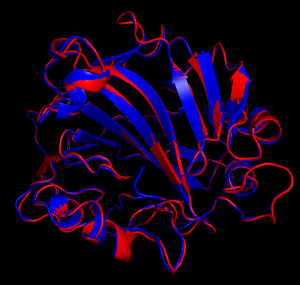

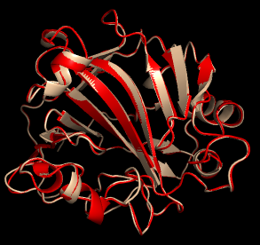

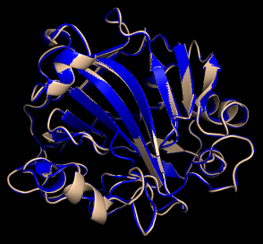

Alignments for Carbonic anhydrase 2 (PDB 1CA2).

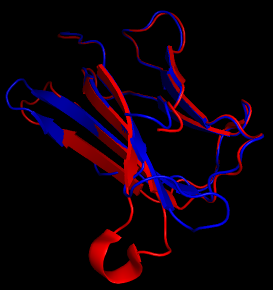

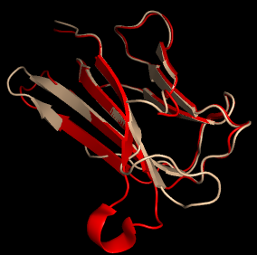

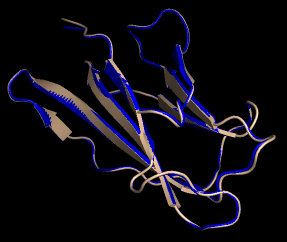

Alignments for Beta‐2‐microglobulin (PDB 2YXF).

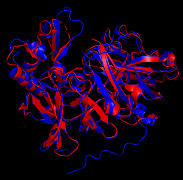

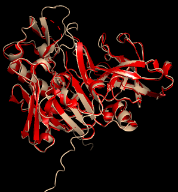

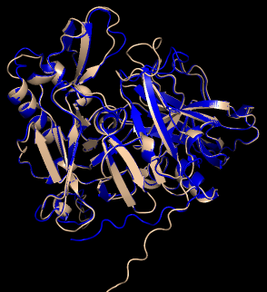

Alignments for Beta-secretase 1 (PDB 2ZHV).

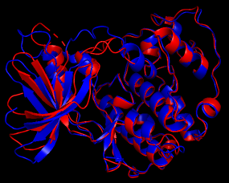

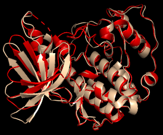

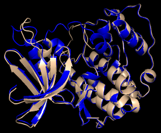

Alignments for Cyclin‐dependent kinase 2 (PDB 1HCK).

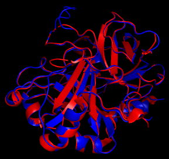

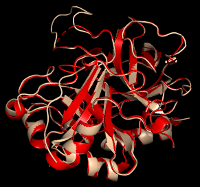

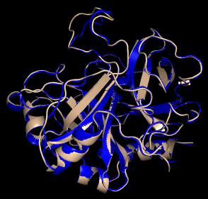

Alignments for Thrombin (PDB 3U69).

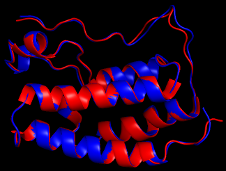

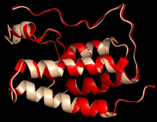

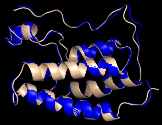

Alignments for Bromodomain‐containing protein 4 BD1 (PDB 2OSS).

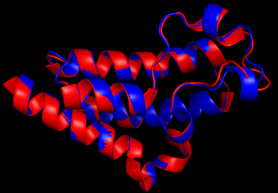

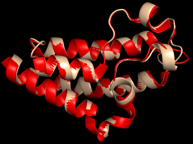

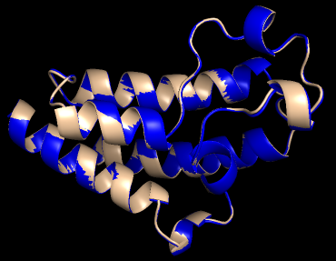

Alignments for Bromodomain‐containing protein 4 BD2 (PDB 7uSK).

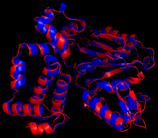

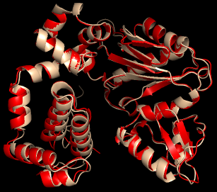

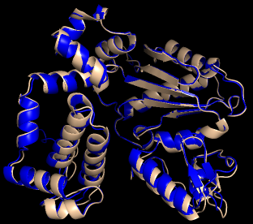

Alignments for DNA polymerase beta (PDB 1BPX).